# HierarchicalClustering

H.C. de Ferrante

24 april 2018

# Motivation

All work so far has been based on whether a chromosome segment was assigned a score of -1, 0, 1 or 2. With a cross-validation procedure, we found that we can classify with an accuracy of just over 80% with gradient-boosted models. However, some loss-of-functions are not necessarily caused by loss of function of a single segment but rather by a e.g. a loss of an entire chromosome arm. Therefore, we want to investigate here if we can increase accuracy further by using metrics that hold for clusters of chromosome segments. Here, we will do so by hierarchical clustering.

The proposed procedure consists of the following:

# 1) Cross-validation procedure.

Cross-validation is done by translating the training split (90% of data) according to one hierarchical clustering. We use “informal” as formally one would have to redo the hierarchical clustering procedure for each fold of the cross-validation procedure. However, we want to stick to `caret` for cross-validation and it is impossible to preprocess data in a custom way for each folds. Thus, let us handwaive.

A defense for this decision may be that correlations can be thought to be relatively stable if we sample 81 out of 90 observations such that the hierarchical clusterings would be similar (so that this handwaiving is not very problematic).

```r
# Set seed for reproducibility and setup parallel computing.
set.seed(9)
cl <- makeCluster(detectCores(), type='PSOCK')
registerDoParallel(cl)

for (i in 1:4) {

  # Do stratisfied sampling for test and training data.
  frac_test <- .1
  train_rows = sample.split(data$Subgroup, SplitRatio=1-frac_test)
  train = data[train_rows,]
  test = data[-which(train_rows),]

  # Parameter grid we want to search using caret with k-fold cross-validation. Also, ensure that the
  # splits for cross-validation are the same for each rho such that we can compare outcome.
  k <- 10
  caretGrid <- expand.grid(interaction.depth=c(1, 2, 3, 5), n.trees = (0:25)*40,
                     shrinkage=c(0.01),
                     n.minobsinnode=c(3,5,10))
  cvfolds <- createFolds(factor(train$Subgroup), k, returnTrain = T)

  # Do grid-search for rho. The function cv.hcgmb.informal uses `caret` for cross-validation.
  rho.grid = seq(0,0.6,0.05)
  results <- lapply(rho.grid, function(rho) cv.hcgbm.informal(train, cvfolds, rho))

  # Save results to a file.
  ldply(results, rbind) %>% write_csv(paste0("data/cv_gbm_results_fold",i,".csv"))
}
# turn parallel processing off and run sequentially again:
registerDoSEQ()
```

# 2) 100 folds with good parameters selected by cross-validation above.

Here, we do the 100 times splitting into test and training and estimating accuracy for both classifiers.

Evaluate outcome:

```r
paste0("Mean accuracy lasso: ",mean(accuracies.lasso),"+-",sd(accuracies.lasso)/sqrt(outerloop_iter))
```

```
## [1] "Mean accuracy lasso: 0.86+-0.00864566219253764"
```

```r
paste0("Mean accuracy GBM: ",mean(accuracies.gbm),"+-",sd(accuracies.gbm)/sqrt(outerloop_iter))
```

```
## [1] "Mean accuracy GBM: 0.842+-0.0092310411770353"
```

# Inspect selected features

```r
merge(lasso.summary, gbm.summary, all = T) %>% arrange(-avg_relInf, -times_selected) %>% head(100) %>% kable()
```

| chrom | times_selected | avg_rank | times_included | avg_relInf |
| --- | --- | --- | --- | --- |
| C17_35076296_35282086 | 100 | 1.000000 | 100 | 551.50827 |
| C12_39197961_41841971 C12_41865312_42212198 C12_42221157_42337973 C12_42372231_42738343 C12_42744201_43936926 C12_43945081_44919712 C12_44923991_45851001 C12_45861893_47611599 C12_47616812_49288718 C1… | 1 | 2.000000 | 1 | 180.18378 |
| C12_39197961_41841971 C12_41865312_42212198 C12_42221157_42337973 C12_42372231_42738343 C12_42744201_43936926 C12_43945081_44919712 C12_44923991_45851001 C12_45861893_47611599 C12_47616812_49288718 C1… | 1 | 2.000000 | 1 | 156.56523 |
| C12_57531034_59041688 C12_59087176_60039028 C12_60060494_62081511 C12_62137202_62802242 C12_62807597_63330914 C12_63340667_63566937 C12_63574243_64694907 C12_64727853_66012212 C12_66035532_66948440 C1… | 10 | 2.000000 | 10 | 147.74379 |
| C12_62137202_62802242 C12_62807597_63330914 C12_63340667_63566937 C12_63574243_64694907 C12_64727853_66012212 C12_66035532_66948440 C12_66954549_67332062 C12_67337260_68268028 C12_68281534_69298703 C1… | 12 | 2.000000 | 12 | 136.09044 |
| C12_57531034_59041688 C12_59087176_60039028 C12_60060494_62081511 C12_62137202_62802242 C12_62807597_63330914 C12_63340667_63566937 C12_63574243_64694907 C12_64727853_66012212 C12_66035532_66948440 C1… | 22 | 2.000000 | 22 | 135.22633 |
| C12_57531034_59041688 C12_59087176_60039028 C12_60060494_62081511 C12_62137202_62802242 C12_62807597_63330914 C12_63340667_63566937 C12_63574243_64694907 C12_64727853_66012212 C12_66035532_66948440 C1… | 20 | 2.000000 | 20 | 130.33607 |
| C12_39197961_41841971 C12_41865312_42212198 C12_42221157_42337973 C12_42372231_42738343 C12_42744201_43936926 C12_43945081_44919712 C12_44923991_45851001 C12_45861893_47611599 C12_47616812_49288718 C1… | 2 | 2.000000 | 2 | 124.82557 |
| C12_62137202_62802242 C12_62807597_63330914 C12_63340667_63566937 C12_63574243_64694907 C12_64727853_66012212 C12_66035532_66948440 C12_66954549_67332062 C12_67337260_68268028 C12_68281534_69298703 C1… | 2 | 2.500000 | 2 | 117.64455 |
| C12_57531034_59041688 C12_59087176_60039028 C12_60060494_62081511 C12_62137202_62802242 C12_62807597_63330914 C12_63340667_63566937 C12_63574243_64694907 C12_64727853_66012212 C12_66035532_66948440 C1… | 2 | 2.000000 | 2 | 111.62582 |
| C12_39143365_39187593 C12_39197961_41841971 C12_41865312_42212198 C12_42221157_42337973 C12_42372231_42738343 C12_42744201_43936926 C12_43945081_44919712 C12_44923991_45851001 C12_45861893_47611599 C1… | 1 | 2.000000 | 1 | 108.08655 |
| C12_57531034_59041688 C12_59087176_60039028 C12_60060494_62081511 C12_62137202_62802242 C12_62807597_63330914 C12_63340667_63566937 C12_63574243_64694907 C12_64727853_66012212 C12_66035532_66948440 C1… | 9 | 2.111111 | 9 | 107.72776 |
| C12_57531034_59041688 C12_59087176_60039028 C12_60060494_62081511 C12_62137202_62802242 C12_62807597_63330914 C12_63340667_63566937 C12_63574243_64694907 C12_64727853_66012212 C12_66035532_66948440 C1… | 1 | 2.000000 | 1 | 104.14363 |
| C12_62137202_62802242 C12_62807597_63330914 C12_63340667_63566937 C12_63574243_64694907 C12_64727853_66012212 C12_66035532_66948440 C12_66954549_67332062 C12_67337260_68268028 C12_68281534_69298703 C1… | 6 | 2.333333 | 6 | 103.78784 |
| C12_100382347_103227744 C12_103235991_103497565 C12_103505239_106694172 C12_106729888_108471654 C12_108480224_109587365 C12_109602873_110653727 C12_110662242_112909433 C12_112932396_115188305 C12_1152… | 6 | 2.166667 | 6 | 101.54004 |
| C12_39197961_41841971 C12_41865312_42212198 C12_42221157_42337973 C12_42372231_42738343 C12_42744201_43936926 C12_43945081_44919712 C12_44923991_45851001 C12_45861893_47611599 C12_47616812_49288718 C1… | 1 | 2.000000 | 1 | 93.44223 |
| C22_15523118_15563672 C22_15579496_15599936 C22_15630903_16476727 C22_16482888_16702519 C22_16710421_17036278 C22_17080555_17294496 C22_17298569_17337860 C22_17343445_17385003 C22_17398378_19199401 C2… | 1 | 3.000000 | 1 | 75.05360 |
| C22_15523118_15563672 C22_15579496_15599936 C22_15630903_16476727 C22_16482888_16702519 C22_16710421_17036278 C22_17080555_17294496 C22_17298569_17337860 C22_17343445_17385003 C22_17398378_19199401 C2… | 1 | 4.000000 | 2 | 71.39396 |
| C12_100382347_103227744 C12_103235991_103497565 C12_103505239_106694172 C12_106729888_108471654 C12_108480224_109587365 C12_109602873_110653727 C12_110662242_112909433 C12_112932396_115188305 C12_1152… | 4 | 2.250000 | 4 | 69.23379 |
| C16_54596059_54845565 C16_54859898_55031124 C16_55038003_56457183 C16_56463550_56765910 C16_56778209_58439142 C16_58452085_59295365 C16_59325545_61138989 C16_61163269_63210535 C16_63246412_66317225 C1… | 8 | 3.500000 | 8 | 66.93294 |
| C22_22725750_22731544 C22_22742616_23009582 C22_23022675_23926329 C22_23930054_23946476 C22_23952881_23967594 C22_23978623_24228038 C22_24263116_24866694 C22_24876788_26191987 C22_26228884_26956916 C2… | 28 | 3.484849 | 33 | 65.94869 |
| C22_17080555_17294496 C22_17298569_17337860 C22_17343445_17385003 C22_17398378_19199401 C22_19209122_19829912 C22_19886024_20632137 C22_20637682_20899315 C22_20906896_21844483 C22_21858001_22597688 C2… | 24 | 4.653846 | 26 | 65.69943 |
| C22_17080555_17294496 C22_17298569_17337860 C22_17343445_17385003 C22_17398378_19199401 C22_19209122_19829912 C22_19886024_20632137 C22_20637682_20899315 C22_20906896_21844483 C22_21858001_22597688 C2… | 3 | 3.666667 | 3 | 63.81463 |
| C22_15433500_15471409 C22_15523118_15563672 C22_15579496_15599936 C22_15630903_16476727 C22_16482888_16702519 C22_16710421_17036278 C22_17080555_17294496 C22_17298569_17337860 C22_17343445_17385003 C2… | 2 | 3.500000 | 2 | 63.33974 |
| C22_22725750_22731544 C22_22742616_23009582 C22_23022675_23926329 C22_23930054_23946476 C22_23952881_23967594 C22_24263116_24866694 C22_24876788_26191987 C22_26228884_26956916 C22_26999547_27819338 C2… | 1 | 3.000000 | 1 | 61.41254 |
| C22_15523118_15563672 C22_15579496_15599936 C22_15630903_16476727 C22_16482888_16702519 C22_16710421_17036278 C22_17080555_17294496 C22_17298569_17337860 C22_17343445_17385003 C22_17398378_19199401 C2… | 26 | 3.884615 | 26 | 60.37380 |
| C6_101081707_101714451 C6_101760344_102800128 C6_102825672_106012872 C6_106034811_106363651 C6_106401543_108269233 C6_108294479_109435745 C6_109441576_110404222 C6_110408187_110448454 C6_110490286_110… | 1 | 3.000000 | 1 | 51.95383 |
| C16_54859898_55031124 C16_55038003_56457183 C16_56463550_56765910 C16_56778209_58439142 C16_58452085_59295365 C16_59325545_61138989 C16_61163269_63210535 C16_63246412_66317225 C16_66324844_67303969 C1… | 16 | 4.062500 | 16 | 48.20175 |
| C6_11346965_12462252 C6_12512986_14535258 C6_1292057_1353261 C6_1358498_1359129 C6_1361599_1435871 C6_14553443_16323782 C6_1535319_2846224 C6_16343597_18497312 C6_18502918_18536678 C6_18550170_1900173… | 1 | 5.000000 | 1 | 43.48427 |
| C6_16343597_18497312 C6_18502918_18536678 C6_18550170_19001738 C6_19049822_20716660 C6_20726739_22048197 C6_22060377_24236375 C6_24244934_26055528 C6_26071233_26265245 C6_26270597_27455236 C6_27464061… | 2 | 5.000000 | 2 | 43.30308 |

[output cut: 70 more lines]

# Plots

Within this section, we include code to generate plots we will use in the report.

## Plots of cross-validation of GBM and rho (all settings)

[figure not shown]

```r
dfs <- lapply(1:4, function(i) read_csv(paste0("data/cv_gbm_results_fold",i,".csv"))) %>% ldply(rbind) %>%
  group_by(shrinkage, interaction.depth, n.minobsinnode, n.trees, rho) %>%
  summarize(mean.cv.accuracy = mean(Accuracy), se.cv.accuracy = sqrt(sum(AccuracySD^2)/40))

labels.mopn <- c("10" = "MOPN: 10", "3" = "MOPN: 3", "5" = "MOPN: 5")
labels.id <- c("1" = "Depth: 1", "2" = "Depth: 3", "3" = "Depth: 3", "5" = "Depth: 5")

dfs %>% ggplot(aes(x=n.trees/100, y=mean.cv.accuracy, col = factor(rho))) +
  geom_line() +
  geom_point(, size = .5) +
  facet_grid(n.minobsinnode ~ interaction.depth, labeller = labeller(n.minobsinnode = labels, interaction.depth = labels.id)) +
  ggtitle("Classification accuracy for different GBM parameters") +
  scale_x_continuous(breaks = seq(0,10,2)) +
  scale_y_continuous(limits = c(.70, .90)) +
  xlab("Number of trees (x100)") +
  ylab("Mean 10-fold CV accuracy on train set (based on 4 iterations)") +
  theme_minimal()
```

```r
dfs %>% arrange(-mean.cv.accuracy) %>% head(100)
```

```
## # A tibble: 100 x 7
## # Groups: shrinkage, interaction.depth, n.minobsinnode, n.trees [82]
##    shrinkage interaction.depth n.minobsinnode n.trees   rho mean.c~ se.cv~
##        <dbl>             <int>          <int>   <dbl> <dbl>   <dbl>  <dbl>
##  1    0.0100                 1              3     120 0.400   0.864 0.0328
##  2    0.0100                 1              3     200 0.400   0.858 0.0308
##  3    0.0100                 1              5     200 0.400   0.858 0.0319
##  4    0.0100                 1              5     240 0.400   0.858 0.0309
##  5    0.0100                 1              3     160 0.400   0.858 0.0318
##  6    0.0100                 1              5     160 0.400   0.857 0.0344
##  7    0.0100                 2              5     120 0.400   0.856 0.0316
##  8    0.0100                 3             10     400 0.400   0.856 0.0338
##  9    0.0100                 1             10     400 0.500   0.855 0.0359
## 10    0.0100                 1              3     280 0.400   0.855 0.0300
## # ... with 90 more rows
```

### Plot restricted to MOPN = 5 and stumps

[output not shown]

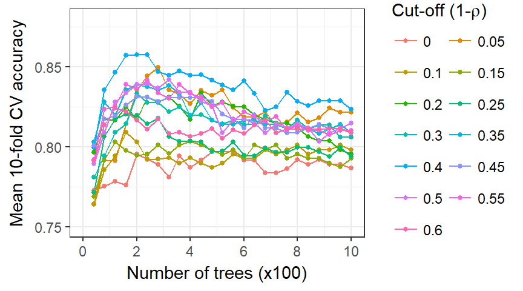

```r
dfs %>% filter(n.minobsinnode == "5", interaction.depth == "1") %>%
  ggplot(aes(x=n.trees/100, y=mean.cv.accuracy, col = factor(rho))) +
  scale_shape_manual(values=shapes) +
  geom_line() +
  geom_point(size=1) +
  scale_x_continuous(breaks = seq(0,10,2)) +
  scale_y_continuous(limits = c(.75, .88)) +
  guides(col = guide_legend(title=TeX("Cut-off ($1-\\rho$)"), ncol = 2, byrow = T)) +
  scale_shape_manual(values=shapes) +
  xlab("Number of trees (x100)") +
  ylab("Mean 10-fold CV accuracy") +
  theme_bw()
```

```r
ggsave("figs/results_cv_gbm_rho.pdf", device="pdf", width = 4.5, height = 3)
```

## Histogram of Spearman correlations

```r
m <- arrange(data,Subgroup)[-1] %>% as.matrix()
corrMatrix <- cor(m, method = "spearman") %>% as.matrix()
corrMatrix[lower.tri(corrMatrix, diag=T)] <- NA
histogram.plot <- corrMatrix %>% melt() %>% filter(is.na(value)==F) %>%
  subset(select=c(value)) %>% ggplot(aes(x=value)) +
  geom_histogram(aes(y=1/100000*..count..), bins = 50, color = "#C13232", fill = "#e09898") +
  xlab(TeX(paste0("Spearman Correlation ($\\rho$)"))) +
  ylab("Count (x 100,000)") +
  theme_classic() +
  scale_y_continuous(position="right") +
  scale_x_continuous(breaks = seq(-0.4,1,.2)) +
  transp.background +
  theme(plot.margin=grid::unit(c(2,0.3,0,2), "cm"))
corrMatrix <- NULL
ggsave("figs/histogram-spearman.pdf", plot = histogram.plot, device="pdf", width=4, height=3)
```

## Global heatmap

Here, we construct a global heatmap. The heatmap will have the customary blue-white-red color coding,

```r
# Get labels for the columns
rowBreaks <- c(0,cumsum(tally(group_by(arrange(data,Subgroup)[1],Subgroup))$n))
labeledRows <- round(1/2*(rowBreaks + lag(rowBreaks)))[-1]
rowLabels <- sapply(1:dim(data)[1], function(index) ifelse(index %in% labeledRows, as.character(arrange(data,Subgroup)$Subgroup[index]),NA))

# Plot the dendogram and color edges by chromosome.
hcd <- cluster_fun(dist_fun(t(m)))

# Get a list of chromosomes by index
colmap.dendro <- head(rep(redBlueMap(4)[2:3], 12),-1)
chromosome.dendro=color_branches(as.dendrogram(hcd, hang = -1), groupLabels = T, col = colmap.dendro, clusters = metadata$Chromosome)

# Reorder based on Euclidean distances between entries.
hcd.row.global <- cluster_fun(dist(m))
global.reorder <- data.frame(spearmanorder = hcd.row.global$order, subgroup = arrange(data,Subgroup)$Subgroup) %>%
  mutate(original_order = row_number()) %>%
  arrange(subgroup,spearmanorder) %>% subset(select=c("original_order")) %>% unlist()
m.reordered <- arrange(data,Subgroup)[global.reorder,-1] %>% as.matrix()

# Create the heatmap and save to pdf.
pdf("Heatmaps/heatmap_global.pdf", height=5, width=8)
lmat <- rbind( c(3,4), c(1,2) )
lwid <- rbind( c(4,1.5))
lhei <- rbind( c(2, 4.5))
heatmap.2(m.reordered, dendrogram = "column", trace = 'none', Rowv = FALSE, Colv = chromosome.dendro,
            hclust = cluster_fun, col = redBlueMap(100),
            distfun = dist_fun, lmat = lmat, lwid = lwid, lhei = lhei, labCol = NA,
            labRow = rowLabels, rowsep = cumsum(count(data,Subgroup)$n)[1:2],
            sepcolor = "black", main = NULL, cexRow = 1.5,
            density.info = "none", margins = c(4.3,0.3))
dev.off()
```

## Local heatmaps

```r
#importantChromosomes <- c(3, 6, 12, 16, 22)

makeHeatmapPerChrom <- function(chromNum, thresh) {

  # Arrange data by subgroup and select data for needed chromosome.
  arranged.data <- arrange(data,Subgroup)
  m.local <- arranged.data[c(FALSE, metadata$Chromosome == chromNum)] %>% as.matrix()

  # Do hierarchical clustering on data and find a single chromosome per cluster. Let this be the middle one for each cluster.
  # (labels become unreadable if we select more)
  hcd.local <- cluster_fun(dist_fun(t(m.local)))
  one_per_cluster <- data.frame(cluster = cutree(hcd.local, h=thresh))
  one_per_cluster$chrom <- rownames(one_per_cluster)
  one_per_cluster <- one_per_cluster %>% group_by(cluster) %>%
    mutate(chrom = ifelse(row_number() == ceiling(n()/2) & n()>=3, chrom, NA)) # Middle observation AND more than 3, then label.

  columnLabels.local <- one_per_cluster$chrom

  # Note rows of the data have been ordered by subgroup and we will separate them by a white line. Only plot labels on the y-axis for
  # the three observations that fall in the middle of the resulting blocks.
  rowBreaks.local <- c(0,cumsum(tally(group_by(arrange(arranged.data,Subgroup)[1],Subgroup))$n))
  rowsNeedingLabels <- round(1/2*(rowBreaks.local + lag(rowBreaks.local)))[-1]
  rowsNeedingLabels.boolean <- rep(NA, dim(arranged.data)[1])
  rowsNeedingLabels.boolean[rowsNeedingLabels] <- as.character(arranged.data$Subgroup[rowsNeedingLabels])

  # To obtain a better visualization, we want to reorder observations within subgroups based on their pairwise correlations. Do this by
  # first doing a hierarchical clustering, then reorder within groups based on this clustering's order.
  hcd.row.local <- cluster_fun(dist(m.local))
  hcd.row.df <- data.frame(Subgroup = arranged.data$Subgroup[hcd.row.local$order], order = hcd.row.local$order) %>%
    mutate(rank = row_number()) %>% arrange(Subgroup, rank) %>% subset(select=c("order")) %>%
    mutate(needsLabel = ifelse(row_number() %in% rowsNeedingLabels, T, F))
  rowLabels.local <- rep(NA,dim(m.local)[1])
  rowLabels.local[hcd.row.df$order[hcd.row.df$needsLabel]] <- as.character(arranged.data$Subgroup[hcd.row.df$order[hcd.row.df$needsLabel]])

  # A row order as `Rowv` argument for heatmap.2 does not work. Let us therefore reorder the original data based on ordering above.
  rearranged.data <- arranged.data[hcd.row.df$order,]
  m.local2 <- rearranged.data[c(FALSE, metadata$Chromosome == chromNum)] %>% as.matrix()

  # Specify height, width and element locations,
  lmat <- rbind(c(5,4,0), c(0,1,0), c(3,2,0),c(0,0,0))
  lhei <- c(3, .5, 8, 1)
  lwid <- c(2, 10, 0)

  # Make heatmap with rearranging the rows and save them to a pdf.
  pdf(paste0("Heatmaps/heatmap",chromNum,".pdf"), height=5, width=10)
  hm <-heatmap.2(m.local2, key=T, dendrogram = "column", trace = 'none', Colv = as.dendrogram(hcd.local), Rowv = NA,
              col = redBlueMap(100), labCol = columnLabels.local, labRow = rowsNeedingLabels.boolean, colsep = NA, margins = c(5,5),
              rowsep = cumsum(count(arranged.data,Subgroup)$n)[1:2], sepcolor = "black", lmat = lmat, lhei = lhei, lwid = lwid,
              ColSideColors=as.character(cutree(hcd.local, h = thresh)), density.info = c("histogram"), srtCol = 45, cexCol = .9,
              key.title="Color Scale & Histogram", main = NA, cex.lab = 1.5, sepwidth = c(0,0.5))
  dev.off()
}

#heatmap.2(m.reordered, dendrogram = "column", trace = 'none', Rowv = FALSE, Colv = chromosome.dendro,
#            hclust = cluster_fun, col = redBlueMap(100),
#            distfun = dist_fun, lmat = lmat, lwid = lwid, lhei = lhei, labCol = NA,
#            labRow = rowLabels, rowsep = cumsum(count(data,Subgroup)$n)[1:2],
#            sepcolor = "black", main = NULL, cexRow = 1.5,
#            density.info = "none", margins = c(4.3,0.3))

# Create the heatmap and save to pdf.
#pdf("Heatmaps/heatmap_global.pdf", height=5, width=8)

ilapply <- function(X, FUN, ...) invisible(lapply(X, FUN, ...))
ilapply(6, makeHeatmapPerChrom, thresh = .4)
```

## Cluster purity and number of clusters.

```r
# Range for Spearman threshold correlations.
rangeThresh <- seq(0,1,0.01)
results <- sapply(rangeThresh, function (thresh) calculateNodeImpurityAndNumClusters(hcd,thresh)) %>%
  unlist() %>% matrix(ncol = 2, byrow = T) %>% as.data.frame()

# Make a single plot showing both.
nObs <- length(allChromosomes)
purity.df <- data.frame(x = rangeThresh, purity = results$V1, numClusters = results$V2)
pcplot <- ggplot(purity.df, aes(x=rangeThresh)) +
  theme_classic() +
  geom_line(aes(y = numClusters, colour =  "Number of clusters")) +
  geom_line(aes(y = purity*nObs, colour = "Fractions cluster pure")) +
  xlab(TeX("$1-\\rho$ threshold")) +
  ylab("Number of clusters") +
  theme(legend.position="top") +
  scale_color_discrete(name=NULL) +
  scale_y_continuous(breaks = seq(0,2500,500), sec.axis = sec_axis(~./nObs, name = "Cluster purity", labels = scales::percent)) + transp.background

ggsave("figs/purNumClusPlot.pdf", plot = pcplot, device="pdf", width=4, height=3)
```

## Perfect correlation between HER2+ and C17_350…

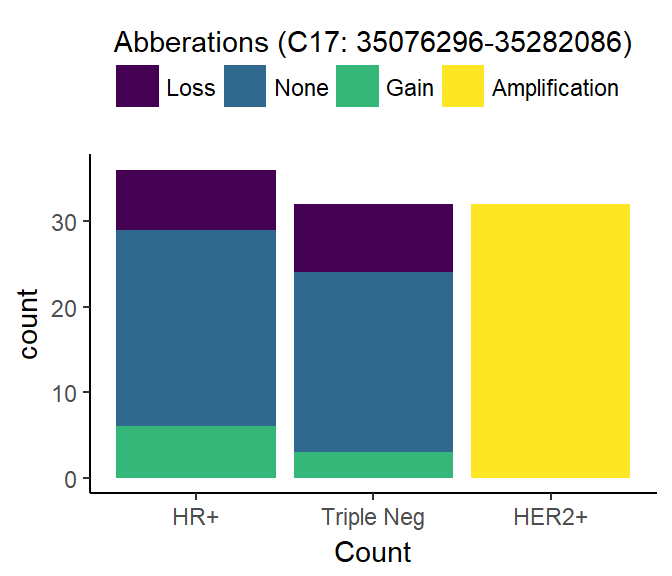

```r
gainlossLabels <- c("-1" = "Loss", "0" = "No change", "1" = "Gain", "2" = "Amplification")
data[c("Subgroup","C17_35076296_35282086")] %>%
  group_by(Subgroup, C17_35076296_35282086) %>%
  summarize(count = n()) %>%
  ggplot(aes(x=Subgroup, y = count, fill = as.factor(C17_35076296_35282086)), labeller = gainlossLabels) +
  geom_col() +
  scale_fill_manual(values=viridis(4),
                       name="Abberations (C17: 35076296-35282086)",
                       breaks=c("-1", "0", "1","2"),
                       labels=c("Loss", "None", "Gain", "Amplification")) +
  theme_classic() +
  theme(legend.position = "top") +
  xlab("Count") +
  guides(fill = guide_legend(title.position="top", title.hjust = 0.5))
```

```r
ggsave("figs/abberations_c17.pdf", device = "pdf")
```